# Whistlepodu

### Bigrams:-

```
From the above Unigrams as we could'nt figure out the positive and negative tweets we can go much deeper and use two tokens to get more information.
```

```python
def generateNGram(cleaned_text,n=2):# bigram          #Writing a function for Ngram where n=2(bigram)
    tokens=cleaned_text.split(" ")
    ngrams = zip(*[tokens[i:] for i in range(n)])
    return ["_".join(ngram) for ngram in ngrams]
```

```python
positive_tweets_bigrams=[" ".join(generateNGram(cleaned_text)) for cleaned_text in positive_tweets]
negative_tweets_bigrams=[" ".join(generateNGram(cleaned_text)) for cleaned_text in negative_tweets]
```

```python
positive_tweets_bigrams[0:5]
```

```
['winter_is is_coming coming_so so_better better_to to_with with_thala thala_',
 'chennai_super super_kings kings_',
 'ms_dhoni dhoni_with with_his his_sweetheart sweetheart_pictwittercomtjuny7tsya',
 'achennai_super super_kings kings_',
 '_roarofthelion roarofthelion_msdhoni msdhoni_saakshisrawat saakshisrawat_imjadeja imjadeja_imraina imraina_chennaiipl chennaiipl_dhoniism dhoniism_cricprabhu cricprabhu_ipl ipl_hotstarhelps hotstarhelps_love love_u u_my my_captain captain_cool cool_check check_out out_what what_did did_we we_do do…
```

```python
top_20_positive_bigrams=getMostCommon(positive_tweets_bigrams,topn=20)
top_20_positive_bigrams
```

```
[('super_kings', 1507),
 ('will_win', 1400),
 ('chennai_super', 1153),
 ('of_the', 915),
 ('the_best', 861),
 ('for_the', 860),
 ('the_match', 824),
 ('all_the', 796),
 ('in_the', 714),
 ('chennaiipl_', 710),
 ('win_the', 670),
 ('_', 654),
 ('to_win', 591),
 ('what_a', 513),
 ('csk_csk', 492),
 ('won_the', 481),
 ('to_the', 450),
 ('who_will', 429),
 ('_chennaiipl', 418),
 ('the_super', 418)]
```

```python
top_20_negative_bigrams=getMostCommon(negative_tweets_bigrams,topn=20)
top_20_negative_bigrams
```

```
[('_', 2565),
 ('live_updates', 1613),
 ('updates_', 1604),
 ('csk_csk', 1133),
 ('of_the', 1026),
 ('in_the', 911),
 ('chennaiipl_', 792),
 ('for_the', 775),
 ('_chennaiipl', 522),
 ('what_a', 508),
 ('_csk', 454),
 ('ms_dhoni', 440),
 ('at_the', 398),
 ('is_the', 379),
 ('csk_', 379),
 ('ipl_2019', 368),
 ('to_the', 364),
 ('the_match', 358),
 ('on_the', 343),
 ('in_ipl', 324)]
```

### Plotting Bigrams

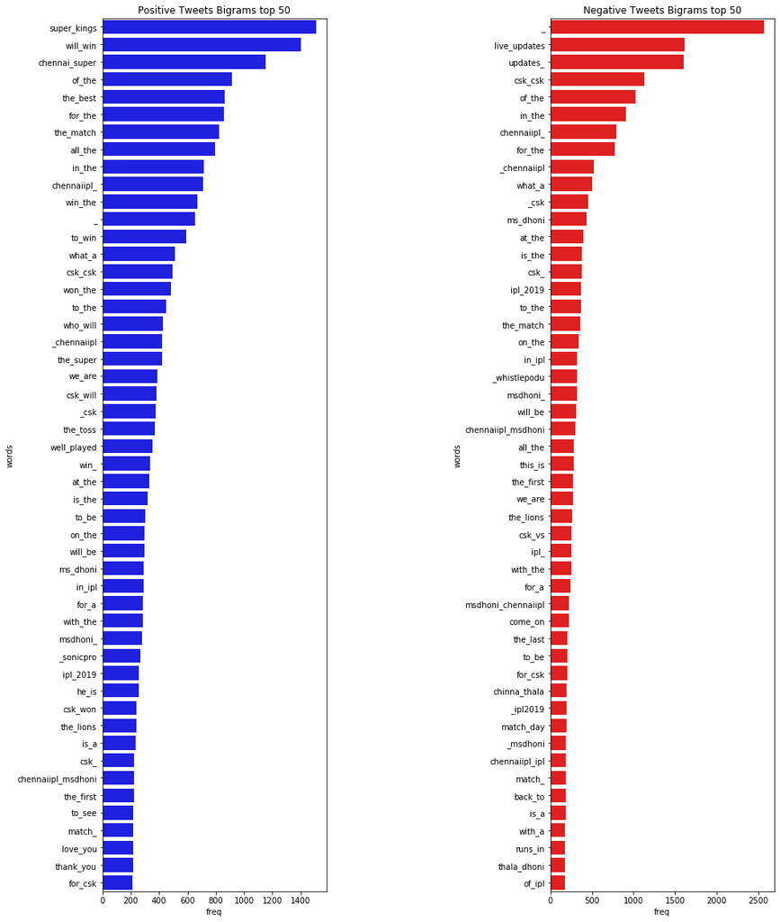

```python
rcParams['figure.figsize'] = 15,20
fig,ax=plt.subplots(1,2)
fig.subplots_adjust(wspace=1) #Adjusts the space between the two plots
plotMostCommonWords(positive_tweets_bigrams,50,"Positive Tweets Bigrams",axis=ax[0])

plotMostCommonWords(negative_tweets_bigrams,50,"Negative Tweets Bigrams",color="red",axis=ax[1])
```

#### "super-kimgs","chennaiipl-msdhoni","love_you","Lions","well played","will win","csk won"-- Shows the love and support from fans in their positive tweets...

#### "chennai ipl","msdhoni","thala dhoni"-- We can say that MSdhoni has the huge fan base from fans than chennai team ("just a thought") by seeing bigrams

### Trigrams:-

```
       Lets see trigrams using three tokens for a better outcome
```

```python
def generateNGram(cleaned_text,n=3):# trigram
    tokens=cleaned_text.split(" ")
    ngrams = zip(*[tokens[i:] for i in range(n)])
    return ["_".join(ngram) for ngram in ngrams]
```

```python
positive_tweets_trigrams=[" ".join(generateNGram(cleaned_text)) for cleaned_text in positive_tweets]
negative_tweets_trigrams=[" ".join(generateNGram(cleaned_text)) for cleaned_text in negative_tweets]
```

```python
top_20_positive_trigrams=getMostCommon(positive_tweets_trigrams,topn=20)
top_20_positive_trigrams
```

```
[('chennai_super_kings', 1122),
 ('will_win_the', 429),
 ('csk_csk_csk', 426),
 ('all_the_best', 376),
 ('who_will_win', 375),
 ('win_the_match', 357),
 ('csk_will_win', 337),
 ('won_the_toss', 250),
 ('of_the_match', 166),
 ('the_toss_and', 161),
 ('__', 154),
 ('will_win_', 144),
 ('super_kings_', 138),
 ('will_win_today', 136),
 ('the_super_kings', 133),
 ('_chennai_super', 127),
 ('won_the_match', 125),
 ('my_perfect_screenshot', 124),
 ('sonicpro_csk_will', 123),
 ('_sonicpro_csk', 119)]
```

```python
top_20_negative_trigrams=getMostCommon(negative_tweets_trigrams,topn=20)
top_20_negative_trigrams
```

```
[('live_updates_', 1586),
 ('updates__', 1581),
 ('csk_csk_csk', 1012),
 ('__', 356),
 ('', 275),
 ('of_the_match', 152),
 ('photo_by_ipl', 112),
 ('top_of_the', 101),
 ('follow_us_tdhtvoffl', 98),
 ('bleed_yellow_for', 97),
 ('for_a_reason', 96),
 ('what_about_you', 93),
 ('i_bleed_yellow', 92),
 ('man_of_the', 92),
 ('tonight_i_bleed', 91),
 ('yellow_for_at', 91),
 ('on_star_sports', 91),
 ('pm_on_star', 90),
 ('star_sports_what', 90),
 ('sports_what_about', 90)]
```

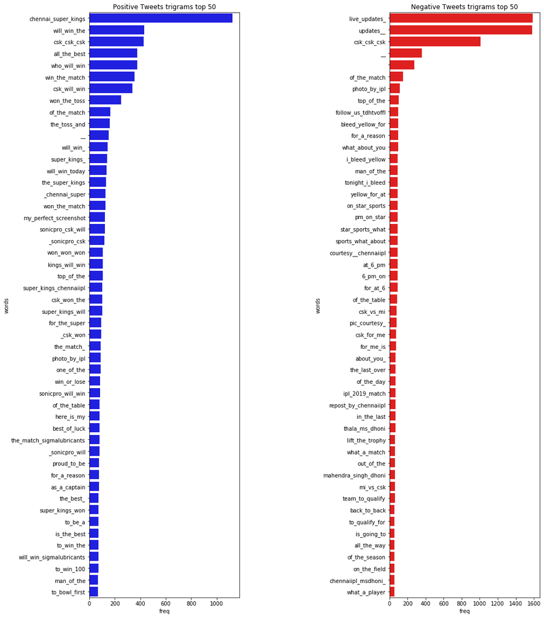

```python
rcParams['figure.figsize'] = 15,20
fig,ax=plt.subplots(1,2)
fig.subplots_adjust(wspace=1) #Adjusts the space between the two plots
plotMostCommonWords(positive_tweets_trigrams,50,"Positive Tweets trigrams",axis=ax[0])

plotMostCommonWords(negative_tweets_trigrams,50,"Negative Tweets trigrams",color="red",axis=ax[1])
```

#### Positive Tweets talks about "CSK will win","kings will win","csk won","won the match","super kings won"--- Shows the confidence levels and the trust they kept on csk .

#### Words like "csk csk csk" is repeated in both positive and negative tweets

#### "Lift the Trophy", "what a player" shows Negative Tweets

### Using 4 Tokens

```python
def generateNGram(cleaned_text,n=4):
    tokens=cleaned_text.split(" ")
    ngrams = zip(*[tokens[i:] for i in range(n)])
    return ["_".join(ngram) for ngram in ngrams]
```

```python
positive_tweets_moregrams=[" ".join(generateNGram(cleaned_text)) for cleaned_text in positive_tweets]
negative_tweets_moregrams=[" ".join(generateNGram(cleaned_text)) for cleaned_text in negative_tweets]
```

```python
top_20_positive_moregrams=getMostCommon(positive_tweets_moregrams,topn=20)
top_20_positive_moregrams=getMostCommon(positive_tweets_moregrams,topn=20)
```

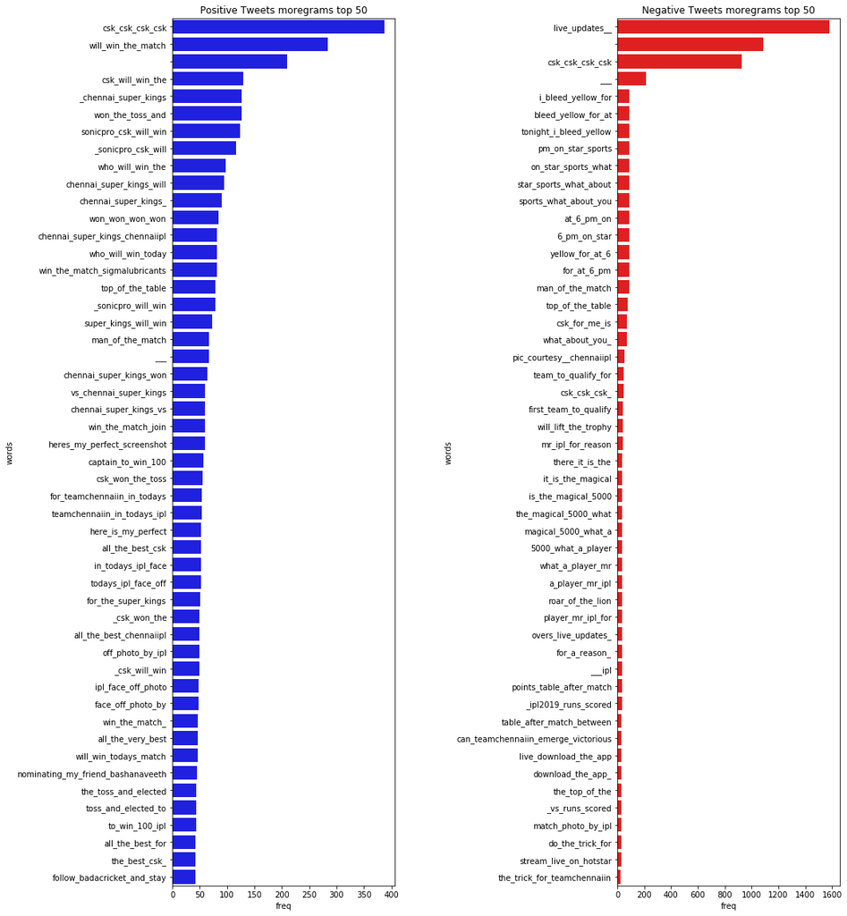

```python
rcParams['figure.figsize'] = 15,20
fig,ax=plt.subplots(1,2)
fig.subplots_adjust(wspace=1) #Adjusts the space between the two plots
plotMostCommonWords(positive_tweets_moregrams,50,"Positive Tweets moregrams",axis=ax[0])

plotMostCommonWords(negative_tweets_moregrams,50,"Negative Tweets moregrams",color="red",axis=ax[1])
```

#### "win the match","all the best csk","csk won","will win todays match"-- shows the confidence levels of fans and support from fans to csk.

#### Its intresting insight that the word " The Magical 5000" refers to SureshRaina's 5000 runs in IPL but its interesting that it has come in Negative Tweets.So, i searched for Suresh Raina's score in this IPL he scored just 380 runs which is one of the least maybe this is the reason for Negative tweets.

#### Most Common Words occured in Unigrams,Bigrams,Trigrams are 'chennaiipl','csk csk csk','csk won','thala','msdhoni','chennaisuperkings', etc

### Word Cloud

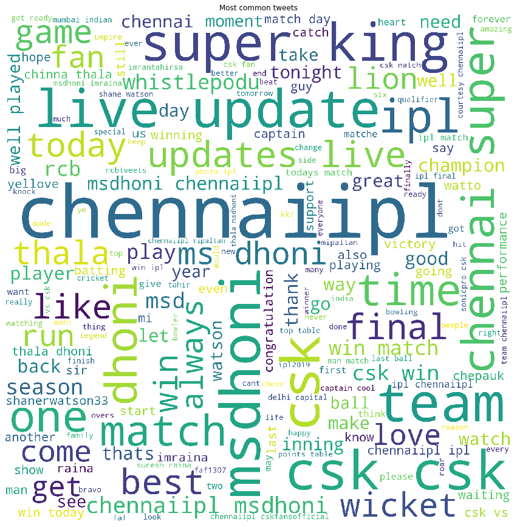

```python
import matplotlib.pyplot as plt
from wordcloud import WordCloud
wordcloud = WordCloud(height=2000, width=2000, stopwords=set(stopwords.words('english')), background_color='white')
wordcloud = wordcloud.generate(' '.join(tweets1['cleaned_text'].tolist()))
plt.imshow(wordcloud)
plt.title("Most common tweets")
plt.axis('off')
plt.show()
```

##### The Above Word Cloud shows the most common tweets of Chennai Super Kings

##### Words like Chennaiipl,msdhoni, csk,thala are the most occured words

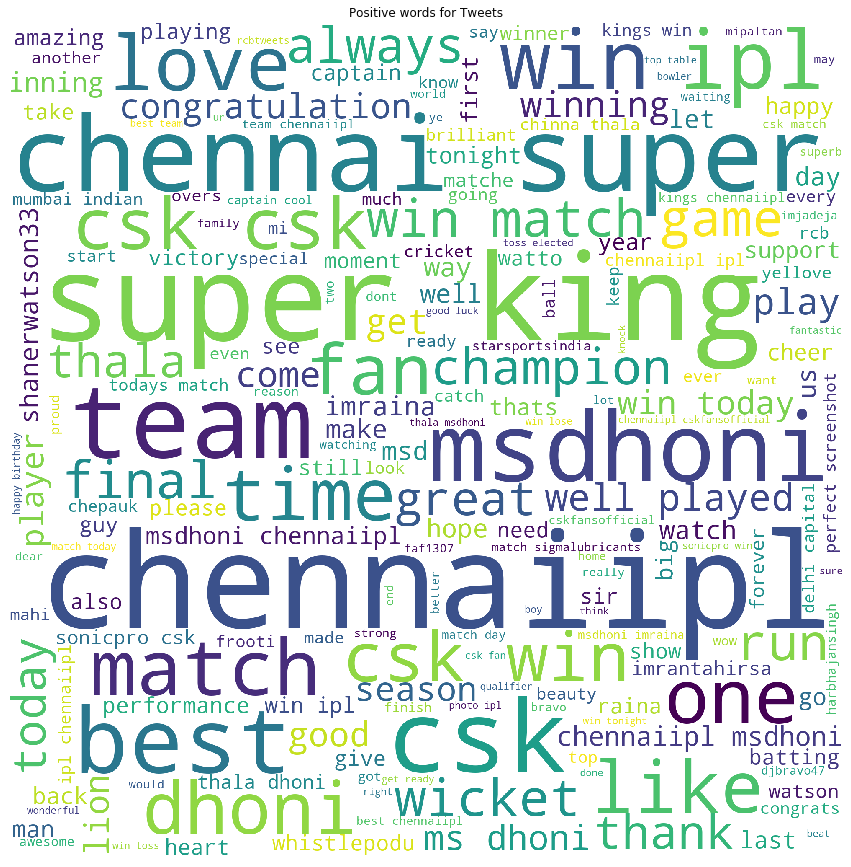

```python
from wordcloud import WordCloud
wordcloud = WordCloud(height=2000, width=2000, stopwords=set(stopwords.words('english')), background_color='white')
wordcloud = wordcloud.generate(' '.join(tweets1.loc[tweets1['sentiment']=='positive','cleaned_text'].tolist()))
plt.imshow(wordcloud)
plt.title("Positive words for Tweets")#positive tweets
plt.axis('off')
plt.show()
```

### Positive Tweets Word Cloud

### Includes Words like Chennaiipl,csk win,best, dhoni are most occured words

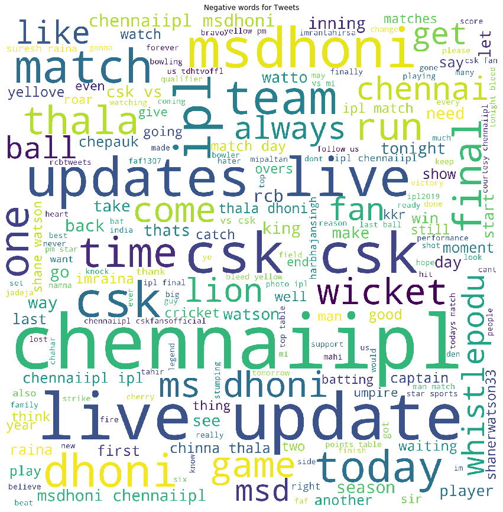

```python
wordcloud = WordCloud(height=2000, width=2000,stopwords=set(stopwords.words('english')), background_color='white')
wordcloud = wordcloud.generate(' '.join(tweets1.loc[tweets1['sentiment']=='negative','cleaned_text'].tolist()))
plt.imshow(wordcloud)
plt.title("Negative words for Tweets")#negative tweets
plt.axis('off')
plt.show()
```

#### Negative Tweets WordCloud

#### Chennaiipl,wicket,live update, msdhoni are most occured in negative tweets

```python
tweets1.head()
```

|  | datetime | is_reply | is_retweet | nbr_favorite | nbr_reply | nbr_retweet | text | usernameTweet | len_message | hashtags | year | time | month | date | cleaned_text | comp_score | sentiment |
| --- | --- | --- | --- | --- | --- | --- | --- | --- | --- | --- | --- | --- | --- | --- | --- | --- | --- |
| 0 | 2019-03-20 06:21:01 | True | False | 1 | 0 | 0 | Winter is coming!! So better to with Thala. #Y... | abhi_gadia | 10 | [#Yellove, #WhistlePodu] | 2019 | 06:21:01 | 3 | 20 | winter is coming so better to with thala | 0.5777 | positive |
| 1 | 2019-03-20 06:32:57 | False | False | 1 | 1 | 0 | he is coming.... \n#WhistlePodu ... https://... | ashutosh2369 | 9 | [#WhistlePodu] | 2019 | 06:32:57 | 3 | 20 | he is coming | 0.0000 | negative |
| 2 | 2019-03-20 06:40:32 | False | False | 0 | 0 | 0 | @ DJBravo47 is all set for getting married ... | vatsan_18 | 14 | [#WhistlePodu] | 2019 | 06:40:32 | 3 | 20 | djbravo47 is all set for getting married chen... | 0.0000 | negative |
| 3 | 2019-03-20 06:51:10 | False | False | 739 | 2 | 137 | March 23rd Will be Long Wait For CSK Fans..! J... | kettavan_Memes | 38 | [#CSK, #IPL2019, #WhistlePodu] | 2019 | 06:51:10 | 3 | 20 | march 23rd will be long wait for csk fans just... | 0.2732 | negative |
| 4 | 2019-03-20 06:54:40 | False | False | 1 | 0 | 0 | # ChennaiSuperKings Match Schedule... @Chen... | itsmr_chowdhary | 14 | [#WhistlePodu, #Yellove, #YelloveAgain] | 2019 | 06:54:40 | 3 | 20 | chennaisuperkings match schedule chennaiipl m... | 0.0000 | negative |

### Elbow Method

```python
from sklearn.feature_extraction.text import CountVectorizer
```

```python
bow=CountVectorizer()
bow_tweets1 = bow.fit_transform(tweets1['cleaned_text'])
```

```python
len(bow.vocabulary_) # Get number of words in vocabulary
```

```
36710
```

```python
## Let us take an sms and see how BoW modle has transformed it

twe=tweets1.iloc[20]['cleaned_text']
twe
```

```
' roarofthelion a emotionally connected come back story every fans must watch it dont miss it msdhoni chennaiipl pictwittercomctotywiks9'
```

```python
twe_transform=bow.transform([twe])
print(twe_transform)
```

```
  (0, 3093)	1
  (0, 4653)	1
  (0, 5035)	1
  (0, 5237)	1
  (0, 6682)	1
  (0, 7073)	1
  (0, 7331)	1
  (0, 7632)	1
  (0, 10378)	2
  (0, 12853)	1
  (0, 13117)	1
  (0, 13252)	1
  (0, 18352)	1
  (0, 30624)	1
  (0, 32664)	1
  (0, 35360)	1
```

```python
j = bow.transform([twe]).toarray()[0]

print('index\tterm\tcount')
for i in range(len(j)):
    if j[i] != 0:
        print(i, bow.get_feature_names()[i],j[i],sep='\t')
```

```
index	term	count
3093	back	1
4653	chennaiipl	1
5035	come	1
5237	connected	1
6682	dont	1
7073	emotionally	1
7331	every	1
7632	fans	1
10378	it	2
12853	miss	1
13117	msdhoni	1
13252	must	1
18352	pictwittercomctotywiks9	1
30624	roarofthelion	1
32664	story	1
35360	watch	1
```

```python
from sklearn.feature_extraction.text import TfidfVectorizer
tfidf = TfidfVectorizer(
    min_df = 5,
    max_df = 0.95,
    max_features = 8000,
    stop_words = 'english'
)
tfidf.fit(tweets1.cleaned_text)
text = tfidf.transform(tweets1.cleaned_text)
```

### K-Means Clustering

```
Fit 2 clusters
Fit 7 clusters
Fit 12 clusters
Fit 17 clusters
Fit 22 clusters
```

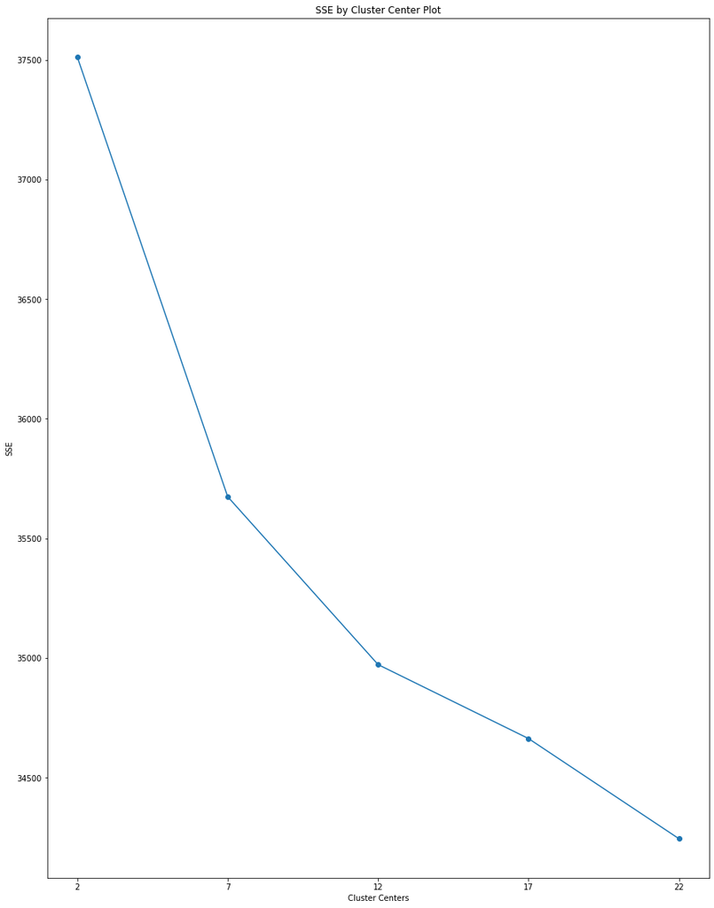

```python
from sklearn.cluster import MiniBatchKMeans
def find_optimal_clusters(tweets1, max_k):
    iters = range(2, max_k+4,5)  # Iteration starting at 2 and ending at 5 clusters with step of 4

    sse = []
    for k in iters:
        sse.append(MiniBatchKMeans(n_clusters=k, init_size=1024, batch_size=2048, random_state=20).fit(tweets1).inertia_)
        print('Fit {} clusters'.format(k))

    f, ax = plt.subplots(1, 1)
    ax.plot(iters, sse, marker='o')
    ax.set_xlabel('Cluster Centers')
    ax.set_xticks(iters)
    ax.set_xticklabels(iters)
    ax.set_ylabel('SSE')
    ax.set_title('SSE by Cluster Center Plot')

find_optimal_clusters(text,22)
```

### By elbow method there are 12 clusters

```python
clusters = MiniBatchKMeans(n_clusters=12, init_size=1024, batch_size=2048, random_state=70).fit_predict(text)
```

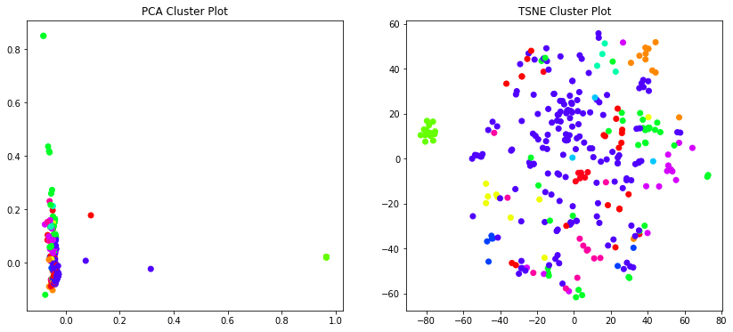

```python
from sklearn.decomposition import PCA
from sklearn.manifold import TSNE
from matplotlib import cm
def plot_tsne_pca(data, labels):
    max_label = max(labels)
    max_items = np.random.choice(range(tweets1.shape[0]), size=3000, replace=False)

    pca = PCA(n_components=2).fit_transform(data[max_items,:].todense())
    tsne = TSNE().fit_transform(PCA(n_components=50).fit_transform(data[max_items,:].todense()))


    idx = np.random.choice(range(pca.shape[0]), size=300, replace=False)
    label_subset = labels[max_items]
    label_subset = [cm.hsv(i/max_label) for i in label_subset[idx]]

    f, ax = plt.subplots(1, 2, figsize=(14, 6))

    ax[0].scatter(pca[idx, 0], pca[idx, 1], c=label_subset)
    ax[0].set_title('PCA Cluster Plot')

    ax[1].scatter(tsne[idx, 0], tsne[idx, 1], c=label_subset)
    ax[1].set_title('TSNE Cluster Plot')

plot_tsne_pca(text, clusters)
```

#### PCA Cluster Plot is not better plot for analysis but TSNE Cluster Plot gives a better visuals.

```python
def get_top_keywords(tweets1, clusters, labels, n_terms):
    df = pd.DataFrame(tweets1.todense()).groupby(clusters).mean()

    for i,r in df.iterrows():
        print('\nCluster {}'.format(i))
        print(','.join([labels[t] for t in np.argsort(r)[-n_terms:]]))

get_top_keywords(text, clusters, tfidf.get_feature_names(), 12)
```

```
Cluster 0
today,mi,photo,win,msdhoni,mipaltan,csk,match,2019,chennaiipl,vs,ipl

Cluster 1
delhi,capitals,csk,ipl,team,match,vs,chennaiipl,win,chennai,super,kings

Cluster 2
match,mahendra,review,singh,thala,csk,ipl,msdhoni,captain,chennaiipl,ms,dhoni

Cluster 3
12,17,19,15,30,kkr,csk,srh,mi,overs,live,updates

Cluster 4
like,fans,fan,time,love,table,day,team,match,msdhoni,chennaiipl,csk

Cluster 5
ipl,choose,wickets,bat,field,bowl,chennaiipl,elected,match,csk,toss,won

Cluster 6
wickets,time,whistlepodu,csk,chennaiipl,win,sports,star,pm,yellow,bleed,tonight

Cluster 7
innings,man,csk,match,courtesy,ipl,imraina,msdhoni,chennaiipl,dhoni,chinna,thala

Cluster 8
watson,game,just,lions,today,runs,super,time,team,msdhoni,match,chennaiipl

Cluster 9
todays,team,lose,chennaiipl,join,sonic,today,sonicpro,sigmalubricants,csk,match,win

Cluster 10
ipl,win,captain,imraina,finisher,luck,csk,match,msdhoni,team,chennaiipl,best

Cluster 11
msdhoni,battle,today,clash,time,thala,match,super,lions,chennaiipl,roar,ready
```

### Topic Modelling

```python
# Data manipulation
import pandas as pd
import numpy as np

# Options for pandas
pd.options.display.max_columns = None
pd.options.display.max_rows = None

pd.options.display.max_colwidth=-1

# Display all cell outputs
from IPython.core.interactiveshell import InteractiveShell
InteractiveShell.ast_node_interactivity = 'all'

from IPython import get_ipython
ipython = get_ipython()

# autoreload extension
if 'autoreload' not in ipython.extension_manager.loaded:
    %load_ext autoreload

%autoreload 2

# Visualizations
import plotly.express as px

import matplotlib.pyplot as plt
import seaborn as sns
import re


import gensim
from gensim import corpora
```

```python
tweets1.head()
```

|  | datetime | is_reply | is_retweet | nbr_favorite | nbr_reply | nbr_retweet | text | usernameTweet | len_message | hashtags | year | time | month | date | cleaned_text | comp_score | sentiment |
| --- | --- | --- | --- | --- | --- | --- | --- | --- | --- | --- | --- | --- | --- | --- | --- | --- | --- |
| 0 | 2019-03-20 06:21:01 | True | False | 1 | 0 | 0 | Winter is coming!! So better to with Thala. #Yellove #WhistlePodu | abhi_gadia | 10 | [#Yellove, #WhistlePodu] | 2019 | 06:21:01 | 3 | 20 | winter is coming so better to with thala | 0.5777 | positive |
| 1 | 2019-03-20 06:32:57 | False | False | 1 | 1 | 0 | he is coming.... \n#WhistlePodu ... https:// twitter.com/ImranTahirSA/s tatus/1108120945460424704 … | ashutosh2369 | 9 | [#WhistlePodu] | 2019 | 06:32:57 | 3 | 20 | he is coming | 0.0000 | negative |
| 2 | 2019-03-20 06:40:32 | False | False | 0 | 0 | 0 | @ DJBravo47 is all set for getting married #WhistlePodu @ChennaiIPL https:// twitter.com/harbhajan_sing h/status/1108037291908329472 … | vatsan_18 | 14 | [#WhistlePodu] | 2019 | 06:40:32 | 3 | 20 | djbravo47 is all set for getting married chennaiipl | 0.0000 | negative |
| 3 | 2019-03-20 06:51:10 | False | False | 739 | 2 | 137 | March 23rd Will be Long Wait For CSK Fans..! Just 3 days To Go For it..! Win or Lose is a Secondary..! Seeing the Lions at the den is the First One..! \n\n#CSK \| #IPL2019 \| #WhistlePodu pic.twitter.… | kettavan_Memes | 38 | [#CSK, #IPL2019, #WhistlePodu] | 2019 | 06:51:10 | 3 | 20 | march 23rd will be long wait for csk fans just 3 days to go for it win or lose is a secondary seeing the lions at the den is the first one pictwittercomhxi3m3zopt | 0.2732 | negative |
| 4 | 2019-03-20 06:54:40 | False | False | 1 | 0 | 0 | # ChennaiSuperKings Match Schedule... @ChennaiIPL @msdhoni @IPL \n@BCCI @BCCIdomestic @ICC #WhistlePodu #Yellove #YelloveAgain pic.twitter.com/W9a7i44YCX | itsmr_chowdhary | 14 | [#WhistlePodu, #Yellove, #YelloveAgain] | 2019 | 06:54:40 | 3 | 20 | chennaisuperkings match schedule chennaiipl msdhoni ipl bcci bccidomestic icc pictwittercomw9a7i44ycx | 0.0000 | negative |

```python
tweets1=tweets1[~pd.isnull(tweets1['cleaned_text'])]
tweets1.shape
#dictionary = corpora.Dictionary(data['cleaned_noun_adj_review'].tolist())
```

```
(38568, 17)
```

```python
### Creating a corpus for Topic Modelling
```

```python
corpus=tweets1['cleaned_text'].tolist()
```

```python
corpus
```

[output not shown]

[output cut: 946 more lines]

[output not shown]

```python
tokenised_corpus=[]
for corp in corpus:

    tokenised_corpus.append([token for token in corp.split(" ")])
tokenised_corpus
```

[output not shown]

[output cut: 13370 more lines]

[output not shown]

```python
dictionary=corpora.Dictionary(tokenised_corpus)
```

```python
len(dictionary)
```

```
36764
```

```python
dictionary[2]
```

```
'coming'
```

```python
doc_term_matrix=[dictionary.doc2bow(rev) for rev in tokenised_corpus]
```

```python
doc_term_matrix[1]
```

```
[(0, 2), (2, 1), (3, 1), (9, 1)]
```

```python
dictionary[13]
```

```
'for'
```

```python
LDA = gensim.models.ldamodel.LdaModel
lda_model=LDA(corpus=doc_term_matrix, id2word=dictionary, num_topics=17,random_state=100,chunksize=1000, passes=50)
```

```python
lda_model.print_topics()
```

```
[(0,
  '0.305*"live" + 0.060*"msd" + 0.049*"yes" + 0.048*"cant" + 0.037*"mahi" + 0.029*"cool" + 0.028*"amazing" + 0.021*"action" + 0.021*"name" + 0.020*"wait"'),
 (1,
  '0.073*"runs" + 0.066*"by" + 0.053*"" + 0.049*"in" + 0.047*"a" + 0.039*"again" + 0.037*"what" + 0.037*"need" + 0.036*"to" + 0.033*"wickets"'),
 (2,
  '0.175*"win" + 0.170*"will" + 0.121*"" + 0.070*"today" + 0.047*"the" + 0.041*"who" + 0.034*"match" + 0.023*"be" + 0.019*"which" + 0.016*"trophy"'),
 (3,
  '0.097*"thala" + 0.087*"over" + 0.064*"4" + 0.058*"mumbai" + 0.058*"last" + 0.053*"run" + 0.043*"ball" + 0.042*"thats" + 0.034*"after" + 0.030*"thanks"'),
 (4,
  '0.203*"super" + 0.144*"chennai" + 0.132*"kings" + 0.026*"yellove" + 0.022*"delhi" + 0.021*"matter" + 0.021*"knock" + 0.019*"king" + 0.015*"winner" + 0.015*"legend"'),
 (5,
  '0.127*"watson" + 0.085*"forever" + 0.055*"whistlepodu" + 0.054*"played" + 0.046*"proud" + 0.035*"shane" + 0.026*"champions" + 0.024*"words" + 0.023*"rt" + 0.021*"enough"'),
 (6,
  '0.127*"1" + 0.116*"finals" + 0.077*"2" + 0.050*"10" + 0.041*"3" + 0.039*"top" + 0.029*"7" + 0.028*"here" + 0.027*"5" + 0.026*"wins"'),
 (7,
  '0.470*"csk" + 0.066*"mi" + 0.053*"won" + 0.042*"join" + 0.019*"done" + 0.018*"matches" + 0.014*"follow" + 0.014*"yet" + 0.013*"us" + 0.012*"vs"'),
 (8,
  '0.221*"dhoni" + 0.066*"ms" + 0.049*"raina" + 0.041*"thala" + 0.038*"catch" + 0.038*"end" + 0.032*"captain" + 0.025*"seasons" + 0.022*"50" + 0.022*"pic"'),
 (9,
  '0.082*"good" + 0.057*"luck" + 0.048*"sir" + 0.038*"hard" + 0.032*"night" + 0.031*"lift" + 0.023*"dear" + 0.022*"champ" + 0.022*"god" + 0.021*"power"'),
 (10,
  '0.134*"chennaiipl" + 0.120*"msdhoni" + 0.066*"ipl" + 0.051*"imraina" + 0.043*"" + 0.026*"cskfansofficial" + 0.022*"harbhajansingh" + 0.022*"by" + 0.020*"for" + 0.016*"never"'),
 (11,
  '0.410*"" + 0.063*"ipl" + 0.054*"updates" + 0.039*"final" + 0.036*"mipaltan" + 0.033*"vs" + 0.030*"chennaiipl" + 0.027*"2019" + 0.026*"match" + 0.013*"congratulations"'),
 (12,
  '0.106*"" + 0.041*"overs" + 0.037*"watto" + 0.025*"for" + 0.025*"tonight" + 0.022*"playoffs" + 0.022*"show" + 0.021*"on" + 0.019*"keep" + 0.018*"were"'),
 (13,
  '0.064*"" + 0.051*"a" + 0.045*"the" + 0.039*"is" + 0.029*"and" + 0.028*"of" + 0.027*"to" + 0.025*"in" + 0.023*"for" + 0.022*"this"'),
 (14,
  '0.089*"" + 0.088*"we" + 0.076*"you" + 0.047*"are" + 0.033*"to" + 0.024*"chennaiipl" + 0.024*"come" + 0.022*"back" + 0.021*"well" + 0.020*"or"'),
 (15,
  '0.078*"my" + 0.076*"love" + 0.071*"you" + 0.063*"u" + 0.055*"i" + 0.044*"shanerwatson33" + 0.034*"team" + 0.030*"always" + 0.028*"is" + 0.027*"thank"'),
 (16,
  '0.167*"the" + 0.058*"" + 0.056*"to" + 0.042*"for" + 0.040*"of" + 0.036*"and" + 0.029*"all" + 0.027*"in" + 0.021*"best" + 0.019*"chennaiipl"')]
```

```python
import pyLDAvis
import pyLDAvis.gensim as gensimvis
pyLDAvis.enable_notebook()
vis=pyLDAvis.gensim.prepare(lda_model,doc_term_matrix,dictionary)
vis
```

[interactive chart not shown]

##### From the 17 topics, we can select any topic and see the frequency of the topic

##### From topic 14, MSdhoni has the highest estimated frequency

##### In topic 12, thala has the estimated frequency of 1500 out of overall frequency

```python
lda_model[doc_term_matrix[1]]
```

```
[(11, 0.19951381), (12, 0.23979035), (13, 0.42343813)]
```

```python
lda_model.show_topic(2)
```

```
[('win', 0.17486353),
 ('will', 0.17015843),
 ('', 0.12085595),
 ('today', 0.0697885),
 ('the', 0.04673892),
 ('who', 0.04059981),
 ('match', 0.033615727),
 ('be', 0.02316784),
 ('which', 0.018873172),
 ('trophy', 0.016196093)]
```

```python
def format_topics_sentences(ldamodel, corpus, texts):
    # Init output
    sent_topics_tweets1 = pd.DataFrame()

    # Get main topic in each document
    for i, row in enumerate(ldamodel[corpus]):

        row = sorted(row, key=lambda x: (x[1]), reverse=True)
        # Get the Dominant topic, Perc Contribution and Keywords for each document
        for j, (topic_num, prop_topic) in enumerate(row):
            if j == 0:  # => dominant topic
                wp = ldamodel.show_topic(topic_num)
                topic_keywords = ", ".join([word for word, prop in wp])
                sent_topics_tweets1 = sent_topics_tweets1.append(pd.Series([int(topic_num), round(prop_topic,4), topic_keywords]), ignore_index=True)
            else:
                break
    sent_topics_tweets1.columns = ['Dominant_Topic', 'Perc_Contribution', 'Topic_Keywords']

    # Add original text to the end of the output
    contents = pd.Series(texts)
    sent_topics_tweets1 = pd.concat([sent_topics_tweets1, contents], axis=1)
    return(sent_topics_tweets1)


tweets1_topic_sents_keywords = format_topics_sentences(ldamodel=lda_model, corpus=doc_term_matrix, texts=corpus)

# Format
tweets1_dominant_topic = tweets1_topic_sents_keywords.reset_index()
tweets1_dominant_topic.columns = ['Document_No', 'Dominant_Topic', 'Topic_Perc_Contrib', 'Keywords', 'Text']

# Show
tweets1_dominant_topic.head(10)
```

|  | Document_No | Dominant_Topic | Topic_Perc_Contrib | Keywords | Text |
| --- | --- | --- | --- | --- | --- |
| 0 | 0 | 13.0 | 0.6314 | , a, the, is, and, of, to, in, for, this | winter is coming so better to with thala |
| 1 | 1 | 13.0 | 0.4231 | , a, the, is, and, of, to, in, for, this | he is coming |
| 2 | 2 | 16.0 | 0.9059 | the, , to, for, of, and, all, in, best, chennaiipl | djbravo47 is all set for getting married chennaiipl |
| 3 | 3 | 16.0 | 0.4799 | the, , to, for, of, and, all, in, best, chennaiipl | march 23rd will be long wait for csk fans just 3 days to go for it win or lose is a secondary seeing the lions at the den is the first one pictwittercomhxi3m3zopt |
| 4 | 4 | 11.0 | 0.3452 | , ipl, updates, final, mipaltan, vs, chennaiipl, 2019, match, congratulations | chennaisuperkings match schedule chennaiipl msdhoni ipl bcci bccidomestic icc pictwittercomw9a7i44ycx |
| 5 | 5 | 4.0 | 0.6118 | super, chennai, kings, yellove, delhi, matter, knock, king, winner, legend | chennai super kings |
| 6 | 6 | 13.0 | 0.5728 | , a, the, is, and, of, to, in, for, this | any guess who is this getting married chennaiipl new delhi |
| 7 | 7 | 8.0 | 0.5248 | dhoni, ms, raina, thala, catch, end, captain, seasons, 50, pic | ms dhoni from last night practice session courtesy chennaiipl pictwittercomumpv4gt7se |
| 8 | 8 | 13.0 | 0.5727 | , a, the, is, and, of, to, in, for, this | any guess who is this getting married chennaiipl new delhi |
| 9 | 9 | 8.0 | 0.8118 | dhoni, ms, raina, thala, catch, end, captain, seasons, 50, pic | ms dhoni with his sweetheart pictwittercomtjuny7tsya |

```python
lda_model.log_perplexity(doc_term_matrix)
```

```
-10.603792728129841
```

```python
from gensim.models import CoherenceModel

coherence_model_lda = CoherenceModel(model=lda_model, texts=tokenised_corpus, dictionary=dictionary,coherence="c_v")
coherence_lda = coherence_model_lda.get_coherence()
print('\nCoherence Score: ', coherence_lda)
```

```
Coherence Score:  0.4290171863917258
```

```python
def compute_coherence_values(dictionary, corpus, texts, limit, start=2, step=3):
    """
    Compute c_v coherence for various number of topics

    Parameters:
    ----------
    dictionary : Gensim dictionary
    corpus : Gensim corpus
    texts : List of input texts
    limit : Max num of topics

    Returns:
    -------
    model_list : List of LDA topic models
    coherence_values : Coherence values corresponding to the LDA model with respective number of topics
    """
    coherence_values = []
    model_list = []
    for num_topics in range(start, limit, step):
        model = LDA(corpus=doc_term_matrix, id2word=dictionary, num_topics=num_topics, random_state=100,chunksize=1000, passes=50)
        model_list.append(model)
        coherencemodel = CoherenceModel(model=model, texts=tokenised_corpus, dictionary=dictionary, coherence='c_v')
        coherence_values.append(coherencemodel.get_coherence())
        print(coherencemodel.get_coherence())

    return model_list, coherence_values
```

```python
model_list,coherence_values = compute_coherence_values(dictionary=dictionary, corpus=doc_term_matrix,texts=tokenised_corpus,start=2,limit=10,step=2)
```

```
0.46831303803868624
0.42572313807233164
0.4770871156210066
0.49231440967775497
```

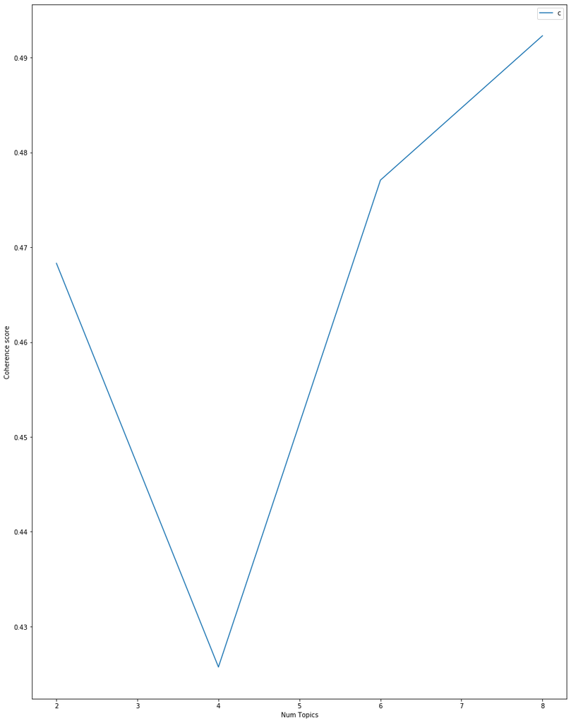

```python
limit=10
start=2
step=2
x = range(start, limit, step)
plt.plot(x, coherence_values)
plt.xlabel("Num Topics")
plt.ylabel("Coherence score")
plt.legend(("coherence_values"), loc='best')
plt.show()
```